# 12.2

Hannes Guth

2023-01-08

## Data exploration

As a first step, the necessary packages will be loaded.

```r
library(naniar) # for missing values analysis
library(data.table) # package to handle the data in the data table format
library(ggplot2) # package to produce graphs
library(klaR) # package to produce the graph for separating the data with a line
library(mda) # package for discriminant analysis
library(caret) # package with several function, here used for the confusionMatrix() function
```

The data will be loaded in the following.

```r
setwd("D:/Dokumente/Studium/Master/Université de Genève/Kurse/Creating Value Through Data Mining/Homework 5/data") # set the working directory
syas <- fread("SystemAdministrators.csv") # read the data as a data table
```

```r
dim(syas) # show the dimensions of the data set
```

```
## [1] 75  3
```

The data set has 75 observations and 3 features.

```r
syas$`Completed task` <- as.factor(syas$`Completed task`) # make completed task a factor
summary(syas) # show the summary of the data set
```

```
##    Experience       Training     Completed task
##  Min.   : 2.70   Min.   :4.000   No :60
##  1st Qu.: 5.20   1st Qu.:4.000   Yes:15
##  Median : 6.30   Median :4.000
##  Mean   : 6.80   Mean   :4.613
##  3rd Qu.: 7.85   3rd Qu.:4.000
##  Max.   :13.70   Max.   :8.000
```

The experience ranges from 2.70 to 13.70 with the central 50% of the data between 5.20 and 7.85. Training ranges from 4.0 until 8.0 but the central 50% equal to 4.00. 1/4 of the administrators who did not completed the task completed the task.

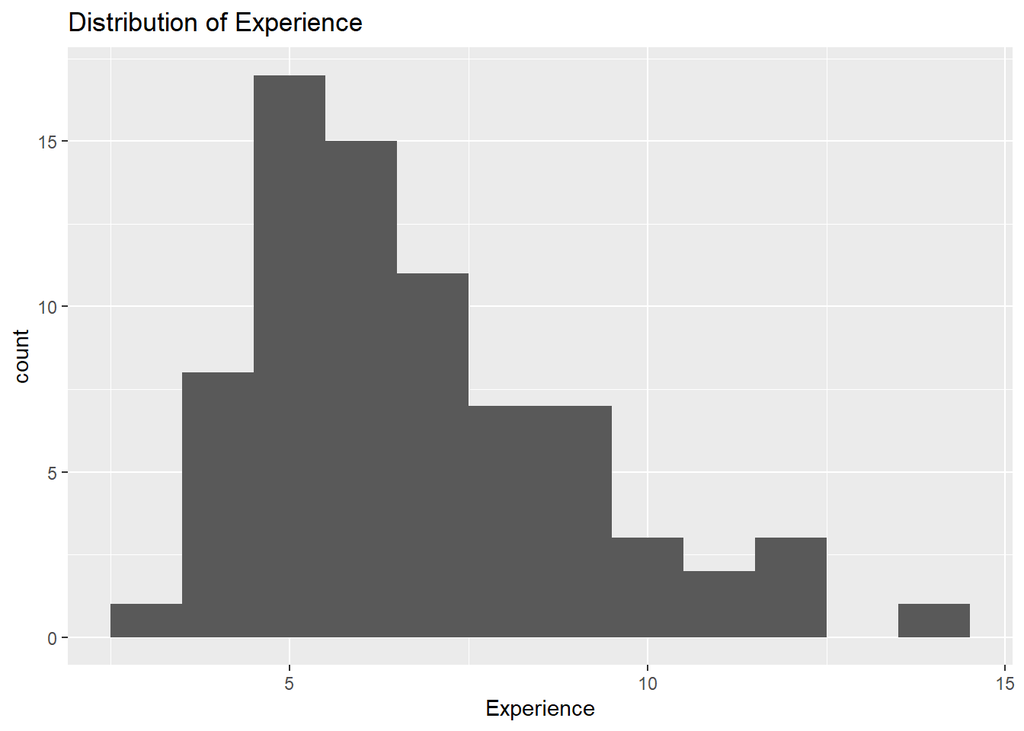

```r
# Plot the distributions of the data set with ggplot
ggplot(syas, aes(x = Experience)) + # create a new ggplot with syas as data and Experience on the x-axis
  geom_histogram(binwidth = 1) + # set binwidth to 1
  labs(title = "Distribution of Experience",
       x = "Experience") # set the labels
```

The distribution of Experience is approximately normal distributed but right skewed.

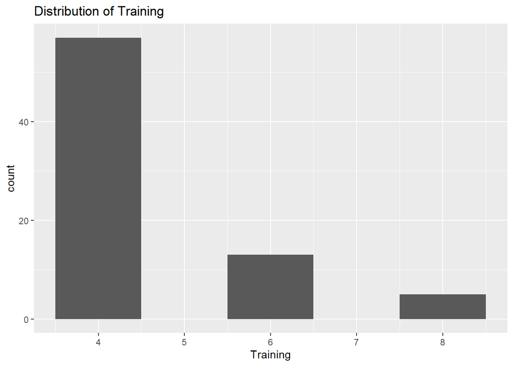

```r
ggplot(syas, aes(x = Training)) + # create a new ggplot with syas as data and Training on the x-axis
  geom_histogram(binwidth = 1) + # set binwidth to 1
  labs(title = "Distribution of Training",
       x = "Training") # set the labels
```

The absolute majority is 4, few observations are at 6 and 8.

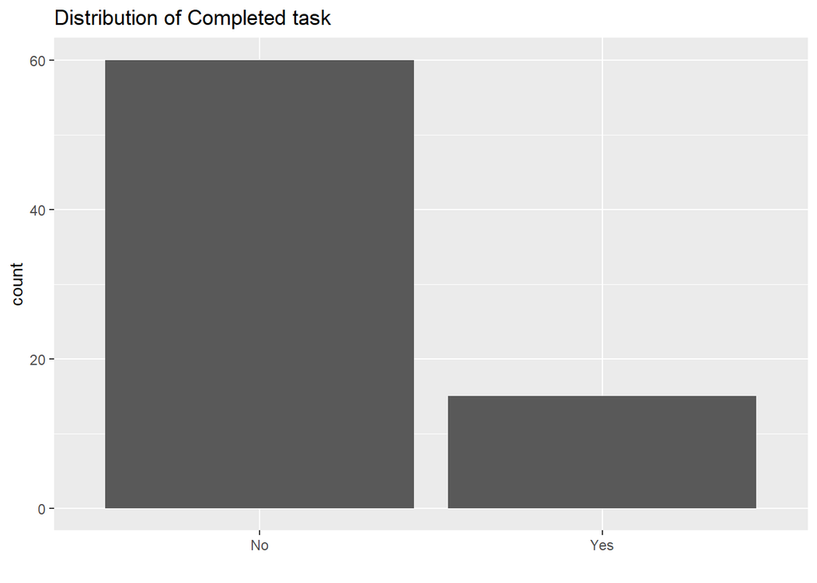

```r
ggplot(syas, aes(x = syas$`Completed task`)) + # create a new ggplot with syas as data and "Completed task" on the x-axis
  geom_bar() + # it shall be a bar plot with default characteristics
  labs(title = "Distribution of Completed task",
       x = "") # set the labels
```

As described above, the 4/5 of the administrators did not complete the task.

The following graph will concern missing values in the data set.

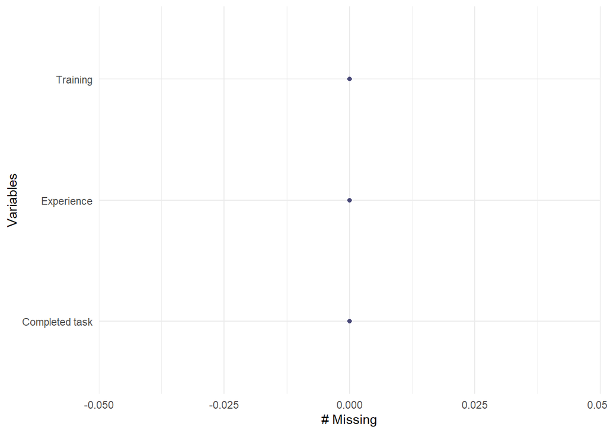

```r
gg_miss_var(syas) # show missing values if there are any
```

There are no missing values in this data set.

## a)

### Create a scatter plot of Experience vs. Training using color or symbol to differentiate administration who completed the tasks from those who did not complete them. See if you can identify a line that separates the two classes with minimum misclassification.

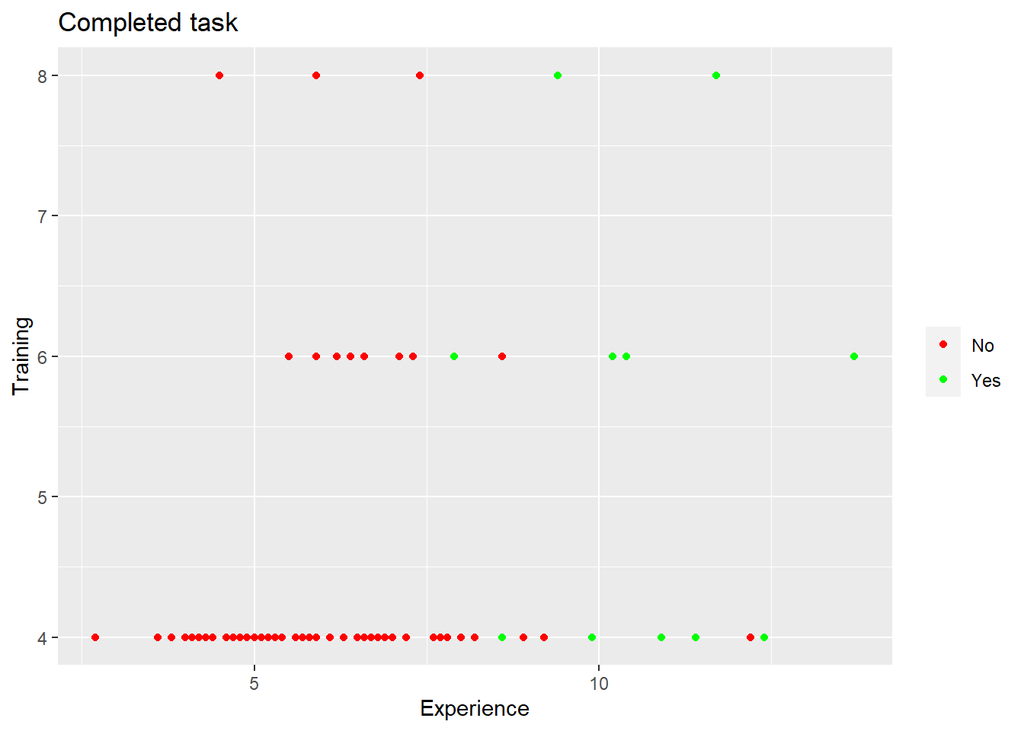

```r
ggplot(syas, aes(x = Experience, y = Training, color = syas$`Completed task`)) + # create a new ggplot with syas as data, setting Experience on the x-axis and Training on the y-axis
  geom_point() + # set the form to a point plot
  scale_color_manual(values = c("red", "green")) + # set the color referring to Completed task
  labs(title = "Completed task") + # set the title
  theme(legend.title=element_blank()) # remove the legend title
```

More green points (administrators who completed the task) have a higher level Experience than those who did not solve the task.

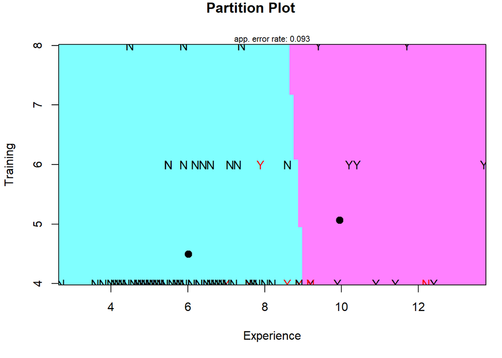

```r
syas$`Completed task` <- as.factor(syas$`Completed task`) # make Completed task a factor
partimat(syas$`Completed task`~ Training + Experience, data = syas, method = "lda") # plot the data, separated by a line that minimizes the error with the help of the partimat function from the klaR package
```

The same conclusion as above can be drawn here.

## b)

### Run a discriminant analysis with both predictors using the entire dataset as training data. Among those who completed the tasks, what is the percentage of administrators who are classified incorrectly as failing to complete the tasks?

```r
discriminantModel <- lda(syas$`Completed task`~ Experience + Training, data = syas) # build the discriminant analysis model with the whole dataset
syas$Prediction <- predict(discriminantModel, syas)$class # make prediction, using the recently created model
confusionMatrix(syas$Prediction, syas$`Completed task`, positive = "Yes") # show the confusion matrix
```

```
## Confusion Matrix and Statistics
##
##           Reference
## Prediction No Yes
##        No  58   5
##        Yes  2  10
##
##                Accuracy : 0.9067
##                  95% CI : (0.8171, 0.9616)
##     No Information Rate : 0.8
##     P-Value [Acc > NIR] : 0.01041
##
##                   Kappa : 0.6847
##
##  Mcnemar's Test P-Value : 0.44969
##
##             Sensitivity : 0.6667
##             Specificity : 0.9667
##          Pos Pred Value : 0.8333
##          Neg Pred Value : 0.9206
##              Prevalence : 0.2000
##          Detection Rate : 0.1333
##    Detection Prevalence : 0.1600
##       Balanced Accuracy : 0.8167
##
##        'Positive' Class : Yes
##
```

5 were classified as failing to complete the task. This is 1/3 of all who completed the task and 7.9% of those classified of not completing the task and 6.67% of all observations.

## c)

### Compute the two classification scores for an administrator with 4 months of experience and 6 credits of training. Based on these, how would you classify this administrator?

```r
newAdministrator <- data.table("Experience" = 4,
                               "Training" = 6) # create a new administrator with the values from the task
predict(discriminantModel, newAdministrator) # predict this new administrator
```

```
## $class
## [1] No
## Levels: No Yes
##
## $posterior
##          No          Yes
## 1 0.9990524 0.0009475719
##
## $x
##         LD1
## 1 -1.601532
```

The model predict with 99.9% probability that this administrator would not complete the task.

## d)

### How much experience must be accumulated by an administrator with 4 training credits before his or her estimated prbability of completing the tasks exceeds 0.5?

This task will be done by evaluating the percentage of completing the task for different levels of experience by using a while loop.

```r
stp <- TRUE # set a stop variable
oldExperience = 0 # set the initial experience value to 0

# find the lowest possible value for experience that lead to the prediction "Yes" by the help of a while loop
while(stp){ # while there has not yet been a value for Experience found that led to the prediction "Yes"
  oldExperience <- oldExperience + 0.1 # increase the level of experience by 0.1 (months)
  # create a new entity with the respective values (the increased Experience and Training = 4)
  newAdministrator <- data.table("Experience" = oldExperience,
                                 "Training" = 4)
  if (predict(discriminantModel, newAdministrator)$posterior[,2] > 0.5){ # if the prediction for this combination is "Yes",
    stp = FALSE # set the stap variable to false to end the loop
    print(paste("Required Experience Level:", oldExperience)) # print the minimum required value for experience
  }
}
```

```
## [1] "Required Experience Level: 9.09999999999998"
```

## e)

### Compare the classification accuracy of this model to that resulting from a logistic regression with cutoff 0.5.

At first, the model will be created and the predictions will be done.

```r
# Sampling
set.seed(1) # reproducibility
trainingIndex <- sample(c(TRUE, FALSE), nrow(syas), replace=TRUE, prob=c(0.6,0.4)) # divide the indiced randomly into training (60 %) and test (40 %)
training <- syas[trainingIndex,] # assign the respective values of trainingIndex to a training data set
test <- syas[!trainingIndex,] # assign the values that have not been assigned the the training set to a test set

# create a logistic regression model with the training set to predict if the task was completed by using Training and Experience as independent variables
logistic_model <- glm(training$`Completed task` ~ Training + Experience,
                      data = training,
                      family = "binomial")

# predict the outcomes for the test set, using the predict function and round the outcome, the cutoff value is therefore 0.5
test$LogisticPrediction <- round(predict(logistic_model,
                                   test,
                                   type = "response")
)
```

Now, the models will be evaluated.

```r
# make the names uniformly with the true outcomes and previous predictions
test$LogisticPrediction[test$LogisticPrediction==1] <- "Yes"
test$LogisticPrediction[test$LogisticPrediction==0] <- "No"

# transform the predictions to factors
test$LogisticPrediction <- as.factor(test$LogisticPrediction)

# show the confusion matrices for both methods, the logistic regression and the discriminant analysis
confusionMatrix(test$LogisticPrediction, test$`Completed task`, positive = "Yes")
```

```
## Confusion Matrix and Statistics
##
##           Reference
## Prediction No Yes
##        No  23   3
##        Yes  0   4
##
##                Accuracy : 0.9
##                  95% CI : (0.7347, 0.9789)
##     No Information Rate : 0.7667
##     P-Value [Acc > NIR] : 0.05693
##
##                   Kappa : 0.6715
##
##  Mcnemar's Test P-Value : 0.24821
##
##             Sensitivity : 0.5714
##             Specificity : 1.0000
##          Pos Pred Value : 1.0000
##          Neg Pred Value : 0.8846
##              Prevalence : 0.2333
##          Detection Rate : 0.1333
##    Detection Prevalence : 0.1333
##       Balanced Accuracy : 0.7857
##
##        'Positive' Class : Yes
##
```

```r
confusionMatrix(test$Prediction, test$`Completed task`, positive = "Yes")
```

```
## Confusion Matrix and Statistics
##
##           Reference
## Prediction No Yes
##        No  22   3
##        Yes  1   4
##
##                Accuracy : 0.8667
##                  95% CI : (0.6928, 0.9624)
##     No Information Rate : 0.7667
##     P-Value [Acc > NIR] : 0.1381
##
##                   Kappa : 0.5862
##
##  Mcnemar's Test P-Value : 0.6171
##
##             Sensitivity : 0.5714
##             Specificity : 0.9565
##          Pos Pred Value : 0.8000
##          Neg Pred Value : 0.8800
##              Prevalence : 0.2333
##          Detection Rate : 0.1333
##    Detection Prevalence : 0.1667
##       Balanced Accuracy : 0.7640
##
##        'Positive' Class : Yes
##
```

Both models have approximately equal performance values. They reach an overall accuracy of 90% and 86.67% and a sensitivity of 57.14%.

## References

### Packages

Tierney N, Cook D, McBain M, Fay C (2021). *naniar: Data Structures, Summaries, and Visualisations for Missing Data*. R package version 0.6.1, https://CRAN.R-project.org/package=naniar.

Dowle M, Srinivasan A (2021). *data.table: Extension of `data.frame`*. R package version 1.14.2, https://CRAN.R-project.org/package=data.table.

H. Wickham. ggplot2: Elegant Graphics for Data Analysis. Springer-Verlag New York, 2016.

Weihs, C., Ligges, U., Luebke, K. and Raabe, N. (2005). klaR Analyzing German Business Cycles. In Baier, D., Decker, R. and Schmidt-Thieme, L. (eds.). Data Analysis and Decision Support, 335-343, Springer-Verlag, Berlin.

Leisch SobTH&RTORpbF, Hornik K, code. BDRBNhcttuot (2022). *mda: Mixture and Flexible Discriminant Analysis*. R package version 0.5-3, https://CRAN.R-project.org/package=mda.

Kuhn M (2022). *caret: Classification and Regression Training*. R package version 6.0-93, https://CRAN.R-project.org/package=caret.